# Section 2 - Ridge Regression

**Student Name: Xinyu Zhang**

**Student ID: 35486244**

## Q4-I Derive the weight update steps

### Solution:

### Expanding and simplifying the loss function

This is the starting point of the derivation: Ridge regression objective function (Loss function + L2)

$ L(w) = \tfrac{1}{2}\|Xw - y\|^2 + \tfrac{\lambda}{2}\|w\|^2 $

$ = \tfrac{1}{2}(Xw - y)^\top (Xw - y) + \tfrac{\lambda}{2}w^\top w $

$ = \tfrac{1}{2}\left(w^\top X^\top X w - w^\top X^\top y - y^\top X w + y^\top y\right) + \tfrac{\lambda}{2}w^\top w $

Since, $ w^\top X^\top y$ and $ y^\top X w$ is the same scalar：

$ = \tfrac{1}{2}w^\top X^\top X w - w^\top X^\top y + \tfrac{1}{2}y^\top y + \tfrac{\lambda}{2}w^\top w $

### Gradient Derivation

Deriving the loss function with respect to w:

$ \tfrac{1}{2} w^\top X^\top X w \;\;\rightarrow\;\; X^\top X w\ $ （use this formula $\tfrac{1}{2} w^\top A w = Aw$，where A is symmetrical）

$ - w^\top X^\top y \;\;\rightarrow\;\; - X^\top y $

$ \tfrac{1}{2} y^\top y \;\;\rightarrow\;\; 0 $

$ \tfrac{\lambda}{2} w^\top w \;\;\rightarrow\;\; \lambda w$

So, $ \nabla_w L(w) = X^\top X w - X^\top y + \lambda w $

Ridge regression analytical solution:

$ w^{*} = \left( X^\top X + \lambda I \right)^{-1} X^\top y $

## Q4-II

#### implement a direct algorithm for Ridge Regression(L2)

```python
# Define the DirectLinearRegressorL2
class DirectLinearRegressorL2:

    def __init__(self, lambda_value=None):
        # init lambda_value：L2 coefficient
        self.lambda_value = lambda_value

    def fit(self, x, y):
        # lhs* w = rhs
        # here x is the feature matrix Phi and y is the target vector t
        rhs = x.T.dot(y)
        lhs = x.T.dot(x) + self.lambda_value * np.eye(x.shape[1])

        # find optimal weights w (coefficients) by solving system
        self.coef_ = np.linalg.solve(lhs, rhs)
        return self

    def predict(self, x):
        return x.dot(self.coef_)
```

## Q4-3

### Study the effect of the L2-regularization on the training and testing errors

### Q4-III-a

#### Consider the ridge regression model for each λ by creating a pipeline of your implemented ridge regressor with a polynomial feature transformer with degree 4.

#### Generate x and y data

```python
import numpy as np
from matplotlib import pyplot as plt
from sklearn.utils import resample
from sklearn.pipeline import Pipeline
from sklearn.metrics import r2_score, mean_squared_error

# define the y(x)
def f(x):
    return np.sin(5*np.pi*x)/(1+2*x)

# Generate x and y data
def make_additive_noise_data(n, f, a, b, noise=0.1**0.5, random_state=None):
    RNG = np.random.default_rng(random_state)
    x = RNG.uniform(a, b, size=(n, 1))
    y = f(x) + RNG.normal(0, noise, size=(n, 1))
    return x, y
```

#### define the polynomial feature transformer

```python
# define the polynomial feature transformer
class PolynomialFeatures:

    def __init__(self, degree):
        self.degree = degree

    def fit(self, x, y=None):
        return self

    def transform(self, x, y=None):
        output = []
        for i in range(0, self.degree+1):
            output.append(x**i)
        return np.column_stack(output)

    def fit_transform(self, x, y=None):
        self.fit(x, y)
        return self.transform(x, y)
```

```python
# intit PolynomialFeatures with degree 4
poly = PolynomialFeatures(4)
```

#### creating a pipeline to combine the polynomial feature and regression model

```python
from sklearn.pipeline import make_pipeline

# Generate x and y data of train and test
x_train, y_train = make_additive_noise_data(20, f, -0.6, 0.6, random_state=1)
x_test, y_test = make_additive_noise_data(20, f, -0.6, 0.6, random_state=1)

# record the all lambda_value
lambda_value = []
for i in range(0, 101):
    lambda_value.append(10**(-10+9*i/100))
lambda_value

# Set different lambda_value to different pipelines
transformation_then_linear = [make_pipeline(poly, DirectLinearRegressorL2(lambda_value=each))
    for each in lambda_value]

transformation_then_linear[1]
```

```
Pipeline(steps=[('polynomialfeatures',
                 <__main__.PolynomialFeatures object at 0x0000025D719CCC70>),
                ('directlinearregressorl2',
                 <__main__.DirectLinearRegressorL2 object at 0x0000025D74CE4730>)])
```

### Q4-III-b

#### Fit each model ten times for all choices of λ.

```python
import numpy as np
from sklearn.utils import resample
from sklearn.metrics import mean_squared_error


def fit_all_models(lambda_values, pipelines, repeat_times=10):
    n_lambdas = len(pipelines)

    # Save the results of each λ in each repeated experiment
    mse_train_all = np.zeros((n_lambdas, n_repeats))
    mse_test_all = np.zeros((n_lambdas, n_repeats))

    # Outer loop: Repeat the experiment repeat_times times (sampling a new training set each time)
    for r in range(repeat_times):
        # Each time samplign a training set of size 20
        x_plus_y = np.hstack((x_train, y_train.reshape(y_train.shape[0], 1)))
        sampled_data = resample(x_plus_y, n_samples=20, random_state=r)
        x_train_sampled = sampled_data[:, :-1]
        y_train_sampled = sampled_data[:, -1:]

        # Inner loop: all lambdas (different pipelines)
        for j, eachpipe in enumerate(pipelines):
            model = eachpipe.fit(x_train_sampled, y_train_sampled)

            # Training set and test set MSE
            y_train_pred = model.predict(x_train_sampled)
            y_test_pred = model.predict(x_test)
            # save the MSE
            mse_train_all[j, r] = mean_squared_error(y_train_sampled, y_train_pred)
            mse_test_all[j, r] = mean_squared_error(y_test, y_test_pred)

    # Average the results of 10 repeating times with the same λ
    mse_train_mean = mse_train_all.mean(axis=1)
    mse_test_mean = mse_test_all.mean(axis=1)

    return mse_train_mean, mse_test_mean, mse_train_all, mse_test_all


# call the fit_all_models
mse_train_mean, mse_test_mean, mse_train_all, mse_test_all = fit_all_models(lambda_value, transformation_then_linear)
```

### Q4-III-c

#### Create a plot of mean squared errors and Discuss λ, model complexity, and error rates, corresponding to underfitting and overfitting

```
C:\Users\Zhang Xinyu\AppData\Local\Temp\ipykernel_62172\578040301.py:4: UserWarning: color is redundantly defined by the 'color' keyword argument and the fmt string "k-" (-> color='k'). The keyword argument will take precedence.
  plt.plot(lambda_value, mse_test_mean, 'k-', linewidth=1, color='red', label = "Test")
```

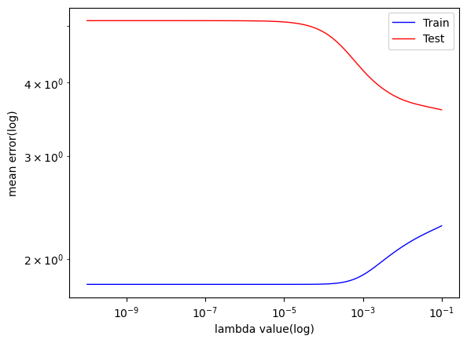

```python
# The horizontal axis is the log λ, and the vertical axis is the log mean square error

plt.plot(lambda_value, mse_train_mean, linewidth=1, color='blue', label = "Train")
plt.plot(lambda_value, mse_test_mean, 'k-', linewidth=1, color='red', label = "Test")
plt.xlabel('lambda value(log)')
plt.ylabel('mean error(log)')
plt.xscale('log')
plt.yscale('log')
plt.legend()
```

#### Discuss λ, model complexity, and error rates, corresponding to underfitting and overfitting

**When λ is very small** (on the left), regularization has little effect, and the model approaches an unconstrained complex model.

As can be seen from the figure, Training error is very low (the blue line at a very low value). Test error is very high (the red line is much higher than the training error).This means the model has learned too much complexity from the training data, resulting in overfitting.

## Q4-IV Would Ridge Regression or Lasso be more appropriate? Why? How would your answer change if interpretability is the top priority?

### Solution

The model may have **highly correlated features (multicollinearity)**. In terms of **predictive stability**, I believe **Ridge regression (loss function + L2 regularization) is a better choice**. This is because Ridge regression distributes the weights of correlated features rather than simply setting the weights of some correlated features to 0, thus ensuring model stability.

From the perspective of **interpretability**, I believe **Lasso regression (loss function + L1 regularization) is more suitable** because it randomly selects one highly correlated feature to retain and discards other correlated features, resulting in a sparse solution. When a model relies on only a small number of features, we can more clearly see which features drive the prediction, thus providing better interpretability.